# Evaluación webinar: Las enfermedades desatendidas en la era de la transición epidemiológica

## Introducción

El webinar se llevó a cabo el día jueves 23 de mayo de 2024 en el marco de la iniciativa “Haciendo Ciencia”, organizada por la Secretaría de Investigación de la Facultad de Bromatología. La disertación estuvo a cargo del Mg. Hernan Hernandez JTP de la asignatura Epidemiología de la Licenciatura en Nutrición. El presente reporte muestra la devolución realizada por 8 participantes del taller.

### ¿Qué tan probable es que recomiendes este Webinar a tus compañeros de la facultad o del trabajo?(Siendo 1 Nada, 5 Mucho)

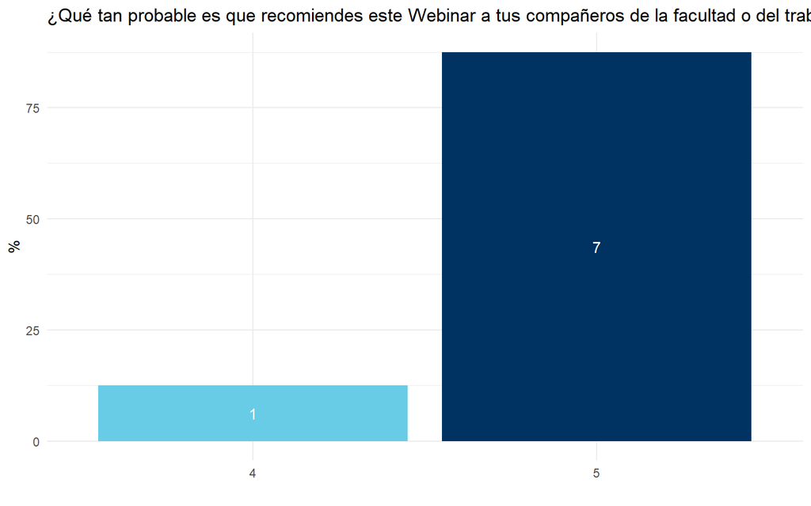

### En general, ¿cómo describirías el taller?

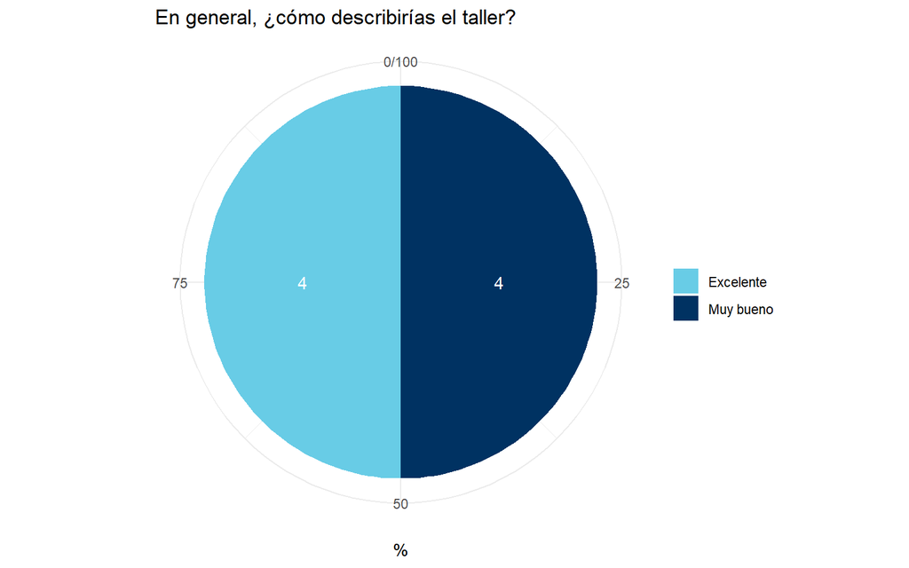

### ¿Qué tan claros fueron los objetivos el webinar?

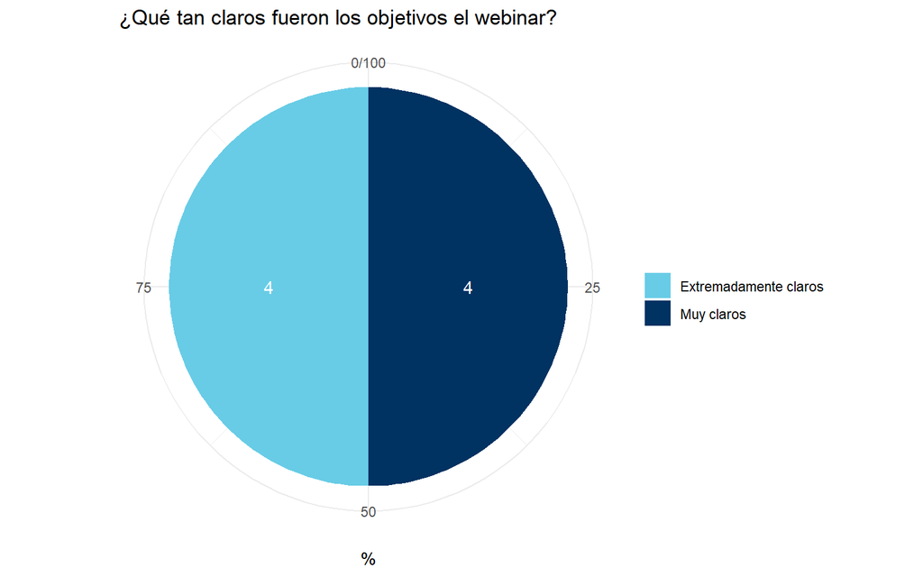

### ¿Cómo calificarías en general al expositor del webinar?

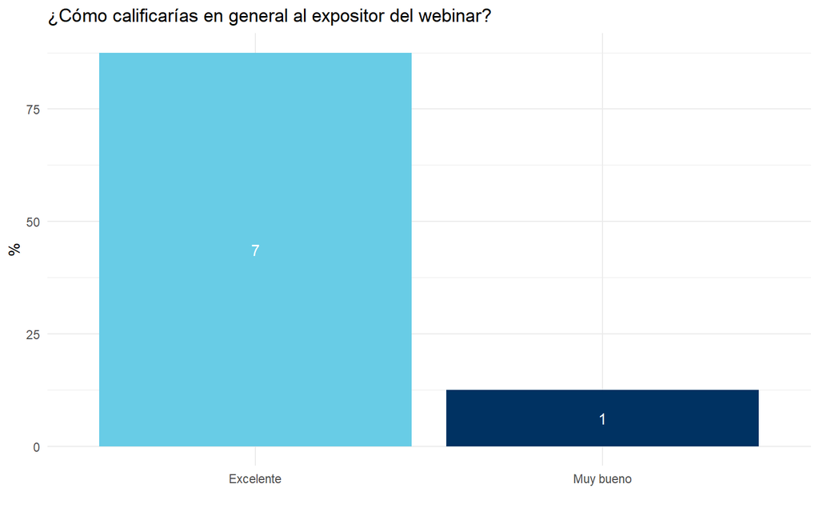

### ¿Qué tan adecuadas te parecieron los temas y metodologías presentados en el webinar?

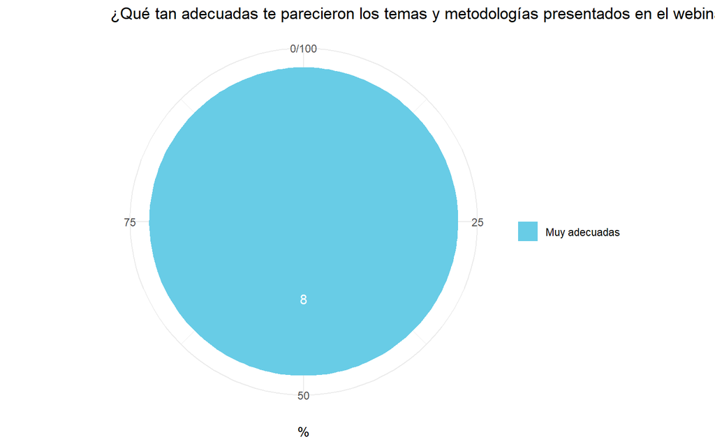

### Por último decinos, sos:

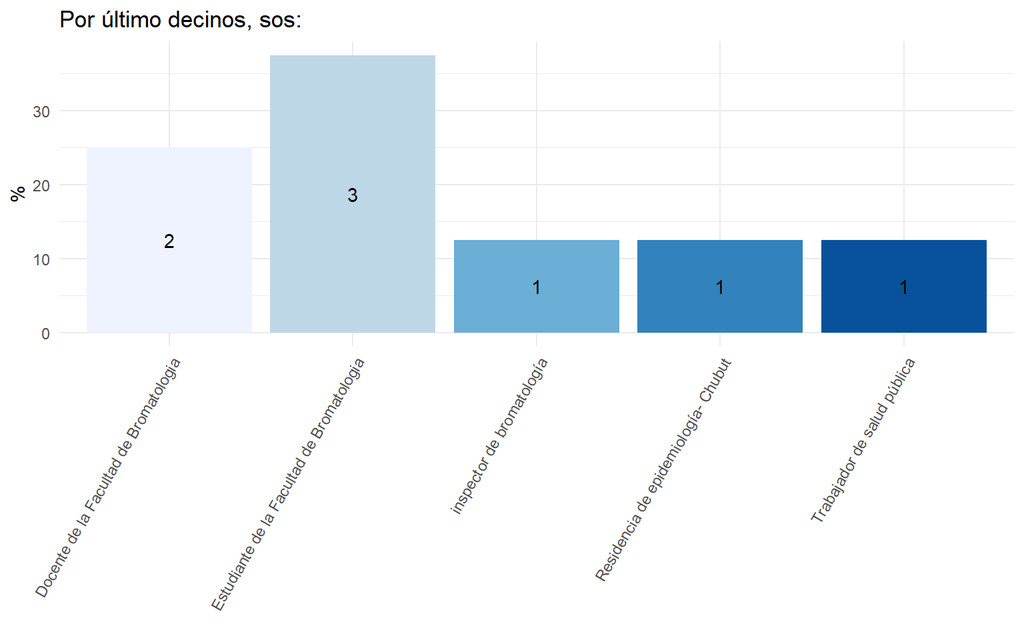

### Otros comentarios

1 Excelente !

2 Como graduada de la Lic. en Nutrición y que trabajé en salud pública y me crucé con varias de las cuestiones abordadas, creo que se podría adaptar este taller a los estudiantes que están realizando sus prácticas, y brindárselos a modo de Seminario.

3 Como estudiante actualmente de la materia Salud pública me pareció super útil el tema tratado, se puede profundizar aún más en relación a las estrategias integradas para reducir el impacto de estas enfermedades y mejorar la calidad de vida de la población